# analise_de_vinho

```python
import pandas as pd
import matplotlib.pyplot as plt
import seaborn as sns
import numpy as np
from sklearn.preprocessing import StandardScaler
from sklearn.linear_model import LogisticRegression
from sklearn.model_selection import train_test_split
from sklearn.metrics import (
    accuracy_score,
    precision_score,
    recall_score,
    f1_score,
    classification_report,
    confusion_matrix,
    roc_curve,
    auc,
    RocCurveDisplay
)
sns.set_style("ticks")
sns.set_context("paper")
%matplotlib inline
```

```python
df = pd.read_csv("archive/winequalityN.csv", sep=",")
df.head()
```

|  | type | fixed acidity | volatile acidity | citric acid | residual sugar | chlorides | free sulfur dioxide | total sulfur dioxide | density | pH | sulphates | alcohol | quality |
| --- | --- | --- | --- | --- | --- | --- | --- | --- | --- | --- | --- | --- | --- |
| 0 | white | 7.0 | 0.27 | 0.36 | 20.7 | 0.045 | 45.0 | 170.0 | 1.0010 | 3.00 | 0.45 | 8.8 | 6 |
| 1 | white | 6.3 | 0.30 | 0.34 | 1.6 | 0.049 | 14.0 | 132.0 | 0.9940 | 3.30 | 0.49 | 9.5 | 6 |
| 2 | white | 8.1 | 0.28 | 0.40 | 6.9 | 0.050 | 30.0 | 97.0 | 0.9951 | 3.26 | 0.44 | 10.1 | 6 |
| 3 | white | 7.2 | 0.23 | 0.32 | 8.5 | 0.058 | 47.0 | 186.0 | 0.9956 | 3.19 | 0.40 | 9.9 | 6 |
| 4 | white | 7.2 | 0.23 | 0.32 | 8.5 | 0.058 | 47.0 | 186.0 | 0.9956 | 3.19 | 0.40 | 9.9 | 6 |

**Faça o download da base - esta é uma base real, apresentada no artigo:** P. Cortez, A. Cerdeira, F. Almeida, T. Matos and J. Reis. Modeling wine preferences by data mining from physicochemical properties. In Decision Support Systems, Elsevier, 47(4):547-553, 2009.

Ela possui uma variável denominada "quality", uma nota de 0 a 10 que denota a qualidade do vinho. Crie uma nova variável, chamada "opinion" que será uma variável categórica igual à 0, quando quality for menor e igual à 5. O valor será 1, caso contrário. Desconsidere a variável quality para o restante da análise.

```python
df['opinion'] = (df['quality'] > 5).astype(int)
df.head()
```

|  | type | fixed acidity | volatile acidity | citric acid | residual sugar | chlorides | free sulfur dioxide | total sulfur dioxide | density | pH | sulphates | alcohol | quality | opinion |
| --- | --- | --- | --- | --- | --- | --- | --- | --- | --- | --- | --- | --- | --- | --- |
| 0 | white | 7.0 | 0.27 | 0.36 | 20.7 | 0.045 | 45.0 | 170.0 | 1.0010 | 3.00 | 0.45 | 8.8 | 6 | 1 |
| 1 | white | 6.3 | 0.30 | 0.34 | 1.6 | 0.049 | 14.0 | 132.0 | 0.9940 | 3.30 | 0.49 | 9.5 | 6 | 1 |
| 2 | white | 8.1 | 0.28 | 0.40 | 6.9 | 0.050 | 30.0 | 97.0 | 0.9951 | 3.26 | 0.44 | 10.1 | 6 | 1 |
| 3 | white | 7.2 | 0.23 | 0.32 | 8.5 | 0.058 | 47.0 | 186.0 | 0.9956 | 3.19 | 0.40 | 9.9 | 6 | 1 |
| 4 | white | 7.2 | 0.23 | 0.32 | 8.5 | 0.058 | 47.0 | 186.0 | 0.9956 | 3.19 | 0.40 | 9.9 | 6 | 1 |

```python
df['type'].value_counts()
```

```
type
white    4898
red      1599
Name: count, dtype: int64
```

```python
#criando novo DataFrame vinho branco
df_white = df[df['type']=='white'].copy()
df_white.drop('quality', axis=1, inplace=True)
```

**Descreva as variáveis presentes na base. Quais são as variáveis? Quais são os tipos de variáveis (discreta, categórica, contínua)? Quais são as médias e desvios padrões?**

```python
#Analise estatistica
df_white.describe()
```

|  | fixed acidity | volatile acidity | citric acid | residual sugar | chlorides | free sulfur dioxide | total sulfur dioxide | density | pH | sulphates | alcohol | opinion |
| --- | --- | --- | --- | --- | --- | --- | --- | --- | --- | --- | --- | --- |
| count | 4890.000000 | 4891.000000 | 4896.000000 | 4896.000000 | 4896.000000 | 4898.000000 | 4898.000000 | 4898.000000 | 4891.000000 | 4896.000000 | 4898.000000 | 4898.000000 |
| mean | 6.855532 | 0.278252 | 0.334250 | 6.393250 | 0.045778 | 35.308085 | 138.360657 | 0.994027 | 3.188203 | 0.489835 | 10.514267 | 0.665169 |
| std | 0.843808 | 0.100811 | 0.120985 | 5.072275 | 0.021850 | 17.007137 | 42.498065 | 0.002991 | 0.151014 | 0.114147 | 1.230621 | 0.471979 |
| min | 3.800000 | 0.080000 | 0.000000 | 0.600000 | 0.009000 | 2.000000 | 9.000000 | 0.987110 | 2.720000 | 0.220000 | 8.000000 | 0.000000 |
| 25% | 6.300000 | 0.210000 | 0.270000 | 1.700000 | 0.036000 | 23.000000 | 108.000000 | 0.991723 | 3.090000 | 0.410000 | 9.500000 | 0.000000 |
| 50% | 6.800000 | 0.260000 | 0.320000 | 5.200000 | 0.043000 | 34.000000 | 134.000000 | 0.993740 | 3.180000 | 0.470000 | 10.400000 | 1.000000 |
| 75% | 7.300000 | 0.320000 | 0.390000 | 9.900000 | 0.050000 | 46.000000 | 167.000000 | 0.996100 | 3.280000 | 0.550000 | 11.400000 | 1.000000 |
| max | 14.200000 | 1.100000 | 1.660000 | 65.800000 | 0.346000 | 289.000000 | 440.000000 | 1.038980 | 3.820000 | 1.080000 | 14.200000 | 1.000000 |

```python
#Detalhando tipos de variaveis
df_white.dtypes
#object  - nao numerico   - qualitativa nominal
#float64 - numero real    - variavel continua
#int32   - numero inteiro - variavel descreta
```

```
type                     object
fixed acidity           float64
volatile acidity        float64
citric acid             float64
residual sugar          float64
chlorides               float64
free sulfur dioxide     float64
total sulfur dioxide    float64
density                 float64
pH                      float64
sulphates               float64
alcohol                 float64
opinion                   int32
dtype: object
```

**4-Com a base escolhida:**

a) Descreva as etapas necessárias para criar um modelo de classificação eficiente.

1 - Limpar NaNs e outliers (usando melhor método - moda, média, regressão linear etc.)

2 - Escolha do modelo

3 - Separar conjunto de treino e teste

4 - Treinar modelo

5 - Rodar modelo com variáveis de teste para comparar o yhat/ypred (previsto no teste) com os targets do y de treino (geralmente y_test)

6 - Utilizar f1-score, acurácia, precisão e recall para analisar a eficiência.

b)Treine um modelo de regressão logística usando um modelo de validação cruzada estratificada com k-folds (k=10) para realizar a classificação. Calcule para a base de teste:

i. a média e desvio da acurácia dos modelos obtidos;

ii. a média e desvio da precisão dos modelos obtidos;

iii. a média e desvio da recall dos modelos obtidos;

iv. a média e desvio do f1-score dos modelos obtidos.

```python
#analisando DataFrame
df_white.shape
```

```
(4898, 13)
```

```python
df_white.info() # checando dados nulos
```

```
<class 'pandas.core.frame.DataFrame'>
Index: 4898 entries, 0 to 4897
Data columns (total 13 columns):
 #   Column                Non-Null Count  Dtype
---  ------                --------------  -----
 0   type                  4898 non-null   object
 1   fixed acidity         4890 non-null   float64
 2   volatile acidity      4891 non-null   float64
 3   citric acid           4896 non-null   float64
 4   residual sugar        4896 non-null   float64
 5   chlorides             4896 non-null   float64
 6   free sulfur dioxide   4898 non-null   float64
 7   total sulfur dioxide  4898 non-null   float64
 8   density               4898 non-null   float64
 9   pH                    4891 non-null   float64
 10  sulphates             4896 non-null   float64
 11  alcohol               4898 non-null   float64
 12  opinion               4898 non-null   int32
dtypes: float64(11), int32(1), object(1)
memory usage: 516.6+ KB
```

```python
df_white.dropna(inplace=True)
```

```python
print(df_white.isnull().sum()) # print dos NaN
```

```
type                    0
fixed acidity           0
volatile acidity        0
citric acid             0
residual sugar          0
chlorides               0
free sulfur dioxide     0
total sulfur dioxide    0
density                 0
pH                      0
sulphates               0
alcohol                 0
opinion                 0
dtype: int64
```

```python
#resetando o index
df_white.reset_index(inplace=True)
```

```python
#apagando o index antigo
df_white = df_white.drop('index', axis=1)
df_white.head()
```

|  | type | fixed acidity | volatile acidity | citric acid | residual sugar | chlorides | free sulfur dioxide | total sulfur dioxide | density | pH | sulphates | alcohol | opinion |
| --- | --- | --- | --- | --- | --- | --- | --- | --- | --- | --- | --- | --- | --- |
| 0 | white | 7.0 | 0.27 | 0.36 | 20.7 | 0.045 | 45.0 | 170.0 | 1.0010 | 3.00 | 0.45 | 8.8 | 1 |
| 1 | white | 6.3 | 0.30 | 0.34 | 1.6 | 0.049 | 14.0 | 132.0 | 0.9940 | 3.30 | 0.49 | 9.5 | 1 |
| 2 | white | 8.1 | 0.28 | 0.40 | 6.9 | 0.050 | 30.0 | 97.0 | 0.9951 | 3.26 | 0.44 | 10.1 | 1 |
| 3 | white | 7.2 | 0.23 | 0.32 | 8.5 | 0.058 | 47.0 | 186.0 | 0.9956 | 3.19 | 0.40 | 9.9 | 1 |
| 4 | white | 7.2 | 0.23 | 0.32 | 8.5 | 0.058 | 47.0 | 186.0 | 0.9956 | 3.19 | 0.40 | 9.9 | 1 |

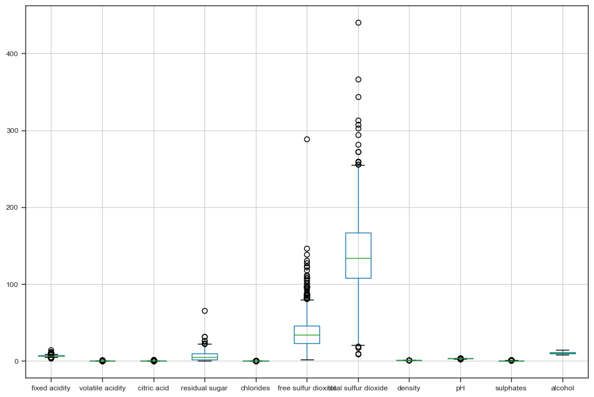

```python
#checando outliers
df_white.drop('opinion', axis=1).boxplot(figsize=[12,8])
```

```python
#limpando outliers free sulfur dioxide > 200
outlier = df_white[df_white['free sulfur dioxide'] > 200 ].index

df_white = df_white.drop(index = outlier)
```

```python
#Criando variaveis regressao logistica
vars = [
   'fixed acidity',
   'volatile acidity',
   'citric acid',
   'residual sugar',
   'chlorides',
   'free sulfur dioxide',
   'total sulfur dioxide',
   'density',
   'pH',
   'sulphates',
   'alcohol'
]
```

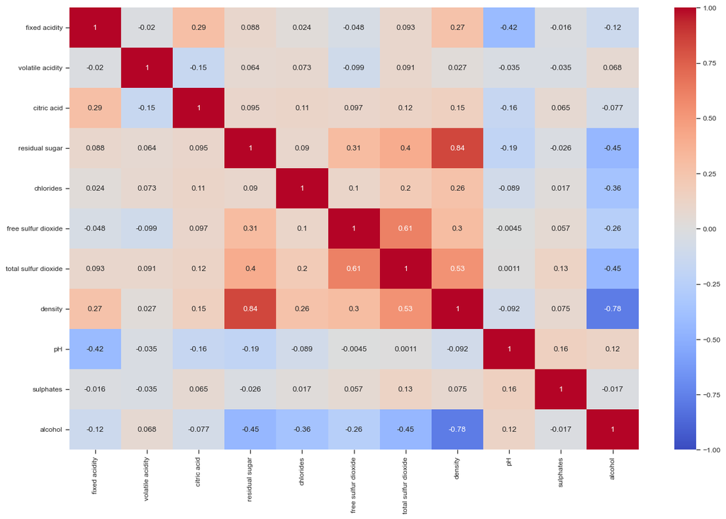

```python
#plotando heatmap
fig, ax = plt.subplots(1, 1, figsize=(16, 10))
sns.heatmap(df_white[vars].corr(), vmax=1, vmin=-1, annot=True, ax=ax, cmap="coolwarm");
```

```python
X_train, X_test, y_train, y_test = train_test_split(df_white[vars],
                                                    df_white['opinion'],
                                                    test_size=0.2,
                                                    random_state=42,
                                                    stratify=df_white['opinion'])

scaler = StandardScaler()
X_train_scaled = scaler.fit_transform(X_train)
X_test_scaled = scaler.transform(X_test)
```

```python
#criando modelo de regressao
logreg = LogisticRegression(max_iter=10000)


logreg.fit(X_train_scaled, y_train)
```

```
LogisticRegression(max_iter=10000)
```

```python
#fazendo predicao
y_hat = logreg.predict_proba(X_train_scaled)
print(y_hat.shape)
```

```
(3895, 2)
```

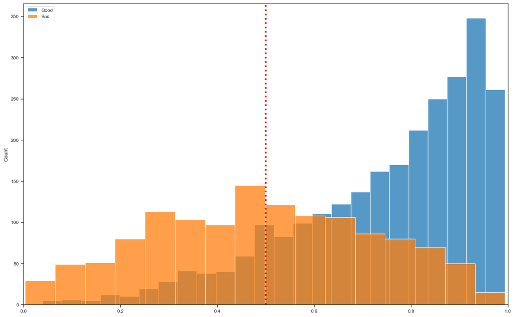

```python
#plotagem
fig, ax = plt.subplots(1, 1, figsize=(16, 10))
sns.histplot(y_hat[y_train.values == 1, 1], label="Good", ax=ax)
ax.set_xlim([0, 1])
sns.histplot(y_hat[y_train == 0, 1], label="Bad", ax=ax)
ax.legend();
ax.axvline(0.5, color="red", ls=":", lw=3);
```

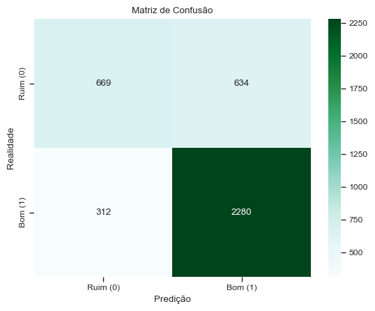

```python
#matrix de confusao
y_pred = logreg.predict(X_train_scaled)

cm = confusion_matrix(y_train, y_pred)

#cm = np.array([[434, 161], [1168, 516]])

ax = sns.heatmap(cm, cmap="BuGn", annot=True, fmt='g')
ax.set_xlabel("Predição")
ax.set_ylabel("Realidade")
ax.set_title("Matriz de Confusão")

ax.set_xticklabels(["Ruim (0)", "Bom (1)"]);
ax.set_yticklabels(["Ruim (0)", "Bom (1)"]);
```

```python
#metricas
precision = cm[1, 1] / (cm[1, 1] + cm[0, 1])

print(f"A precisão é {100*  precision:.2f} %")

accuracy = (cm[0, 0] + cm[1, 1]) / np.sum(cm)

print(f"A acurácia é {100 * accuracy:.2f} %")

# Sensibilidade ou taxa de verdadeiro positivo
sensibility = (cm[1, 1] / (cm[1, 1] + cm[1, 0]))
print(f"A sensibilidade é {100 *  sensibility:.2f} %")

specificity = (cm[0,0] / (cm[0, 0] + cm[0 ,1]))

print(f"A especificidade é {100 * specificity:.2f} %")

# (1 - specificity) ou taxa de falsos positivos

F1_score = 2 *(sensibility * precision) / (sensibility + precision)

print(f"F1 Score =  {F1_score:.2f}")
```

```
A precisão é 78.24 %
A acurácia é 75.71 %
A sensibilidade é 87.96 %
A especificidade é 51.34 %
F1 Score =  0.83
```

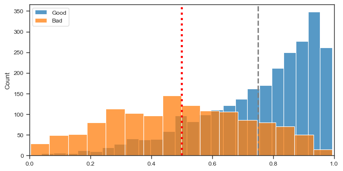

```python
#plottagem da distribuicao
def plot_distributions(model, X, y, ax=None):
    y_hat = model.predict_proba(X)
    if ax == None:
        fig, ax = plt.subplots(1, 1, figsize=(8, 4))
    sns.histplot(y_hat[y.values == 1, 1], label="Good", ax=ax)
    ax.set_xlim([0, 1])
    sns.histplot(y_hat[y == 0, 1], label="Bad", ax=ax)
    ax.legend();
    return ax

ax = plot_distributions(logreg, X_train_scaled, y_train)


ax.axvline(0.5, lw=3, color='red', ls=":");
ax.axvline(0.75, lw=2, color='gray', ls="--")
```

```python
#metodos de metricas
print(f"A acurácia é {100 * accuracy_score(y_train, y_pred):.2f} %")
print(f"A sensibilidade é {100 *  recall_score(y_train, y_pred):.2f} %")
print(f"A precisão é {100*  precision_score(y_train, y_pred):.2f} %")
```

```
A acurácia é 75.71 %
A sensibilidade é 87.96 %
A precisão é 78.24 %
```

```python
#report
print(classification_report(y_train, y_pred))
```

```
              precision    recall  f1-score   support

           0       0.68      0.51      0.59      1303
           1       0.78      0.88      0.83      2592

    accuracy                           0.76      3895
   macro avg       0.73      0.70      0.71      3895
weighted avg       0.75      0.76      0.75      3895
```

```python
#calculando threshold
thresholds = np.linspace(0, 1, 101)
y_hat = logreg.predict_proba(X_train)


for threshold in thresholds:
    predictions = []
    if (y_hat > threshold).any():
        y_pred = 1.
    else:
        y_pred = 0.
    predictions.append(y_pred)
```

```python
#predicao metricas
y_hat = logreg.predict_proba(X_train_scaled)
thresholds = np.linspace(0, 1, 101)

def specificity_score(y, y_pred):
    cm = confusion_matrix(y, y_pred)
    specificity = (cm[0,0] / (cm[0, 0] + cm[0 ,1]))
    return specificity

def predict(model, X, threshold, pos_label=1):
    y_hat = model.predict_proba(X)
    y_pred = []
    for prob_tuple in y_hat:
        prob = prob_tuple[pos_label]
        if (prob > threshold).any():
            y_pred.append(1.)
        else:
            y_pred.append(0.)
    return np.array(y_pred)

#def predict(model, X, threshold, pos_label=1):
#    y_hat = model.predict_proba(X)
#    y_pred = (y_hat[:, pos_label] > threshold)
#    return y_pred.astype(float)
# Probabilidade de ter um vinho bom

recall = []
precision = []
specificity = []
f1 = []
for threshold in thresholds:
    y_pred_thr = predict(logreg, X_train_scaled, threshold)
    recall.append(recall_score(y_train, y_pred_thr))
    precision.append(precision_score(y_train, y_pred_thr))
    specificity.append(specificity_score(y_train, y_pred_thr))
    f1.append(f1_score(y_train, y_pred_thr))
```

```python
#plotagem ROC     fig, ax = plt.subplots(1, 1, figsize=(10, 6))

ax.plot(thresholds, recall, color="orange", label="recall")
ax.plot(thresholds, precision, color="navy", label="precision")
ax.plot(thresholds, f1, color="olive", label="f1")

f1_max = max(f1)
thr_arg_max = np.argmax(f1)
thr_max = thresholds[thr_arg_max]

ax.axvline(thr_max, color="red", ls=":")
ax.axvline(0.5, color="gray",lw=0.5, ls="--")
ax.axhline(f1_max, color="red", ls=":")

ax.legend()
ax.set_ylim([0.5, 1])
print(f"f1 máximo: {f1_max:.2f} - ponto de operação: {thr_max:.2f}")
print(f"Recall: {recall[thr_arg_max]:.2f} - Precision: {precision[thr_arg_max]:.2f}")
sns.despine(offset=10)
```

```
f1 máximo: 0.83 - ponto de operação: 0.49
Recall: 0.89 - Precision: 0.78
```

```python
#verrdadeiro e falso positivo
tpr = recall
fpr = [(1 - s) for s in specificity]
```

```
(0.0, 1.0)
```

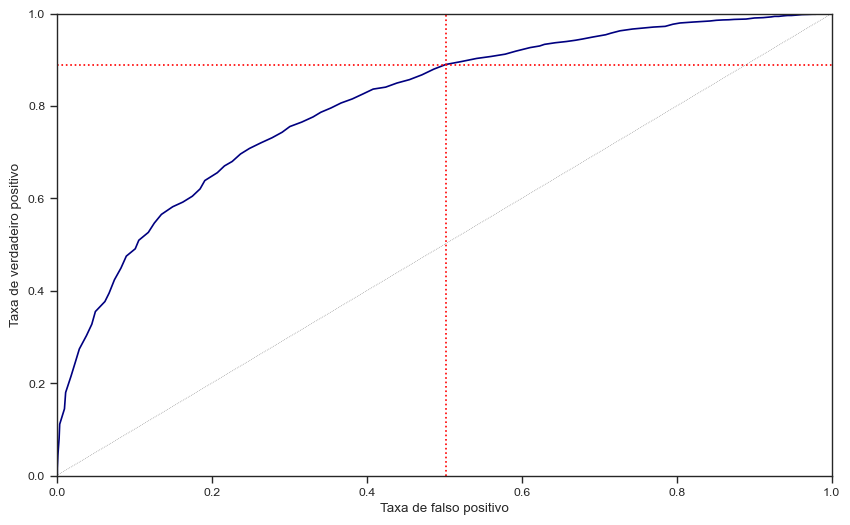

```python
#plotagem de verdadeiro e falso poositivo
fig, ax = plt.subplots(1, 1, figsize=(10, 6))

ax.plot(fpr, tpr, color="navy")
ax.set_ylabel("Taxa de verdadeiro positivo")
ax.set_xlabel("Taxa de falso positivo")

ax.axvline(fpr[thr_arg_max], color="red", ls=":")
ax.axhline(tpr[thr_arg_max], color="red", ls=":")
ax.plot(thresholds, thresholds, color= "gray", ls=":", lw=0.5)
ax.set_ylim([0., 1.])
ax.set_xlim([0., 1.])
```

```python
#area da curva AUC
auc_score = auc(fpr, tpr)
print(f"Area Under Curve (AUC): {auc_score:.2f}")
```

```
Area Under Curve (AUC): 0.80
```

```python
#F1 score
def get_f1_score_list(model, X, y, thresholds):
    list_of_f1 = []
    for threshold in thresholds:
        y_pred = predict(model, X, threshold)
        f1 = f1_score(y, y_pred)
        list_of_f1.append(f1)
    return list_of_f1

def get_max_f1_score(model, X, y, thresholds):
    list_of_f1 = get_f1_score_list(model, X, y, thresholds)
    f1_max = max(list_of_f1)
    f1_arg_max = np.argmax(list_of_f1)
    threshold_max = thresholds[f1_arg_max]
    return f1_max, threshold_max, f1_arg_max


fpr, tpr, thresholds = roc_curve(y_train, y_hat[:, 1], pos_label=1)
auc_score = auc(fpr, tpr)
f1_max, threshold_max, f1_arg_max =  get_max_f1_score(logreg,
                                                      X_train_scaled,
                                                      y_train,
                                                      thresholds)


print(f"Area Under Curve (AUC): {auc_score:.2f}")
print(f"Maximum F1 : {f1_max:.2f} at {threshold_max:.3f}")
```

```
Area Under Curve (AUC): 0.80
Maximum F1 : 0.83 at 0.488
```

```
<sklearn.metrics._plot.roc_curve.RocCurveDisplay at 0x2a8e9cee0e0>
```

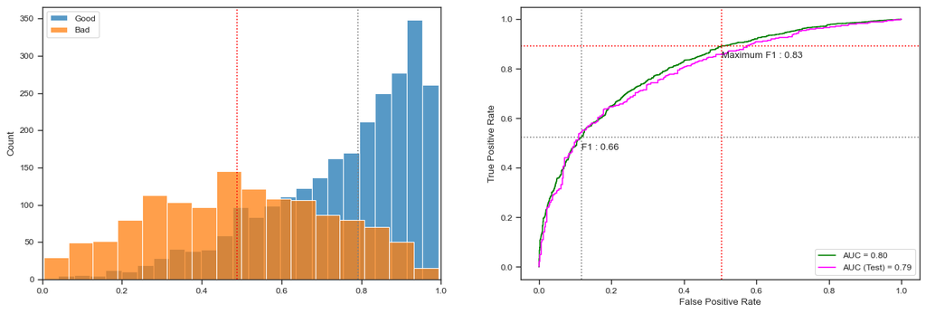

```python
fig, axes = plt.subplots(1, 2, figsize=(16, 5))

threshold_random = 500

# DISTRIBUTION
plot_distributions(logreg, X_train_scaled, y_train, ax=axes[0])
axes[0].axvline(threshold_max, color="red", ls=":")
axes[0].axvline(thresholds[threshold_random], color="gray", ls=":")

# ROC CURVE
RocCurveDisplay(fpr=fpr, tpr=tpr, roc_auc=auc_score).plot(ax=axes[1],color="green")
axes[1].axvline(fpr[f1_arg_max], color="red", ls=":")
axes[1].axhline(tpr[f1_arg_max], color="red", ls=":")
axes[1].annotate(f"Maximum F1 : {f1_max:.2f}", (fpr[f1_arg_max], tpr[f1_arg_max] - 0.05))


f1_list = get_f1_score_list(logreg, X_train_scaled, y_train, thresholds)


axes[1].axvline(fpr[threshold_random], color="gray", ls=":")
axes[1].axhline(tpr[threshold_random], color="gray", ls=":")

axes[1].annotate(f"F1 : {f1_list[threshold_random]:.2f}",
                        (fpr[threshold_random],
                         tpr[threshold_random] - 0.05))


# ROC CURVE Test
y_hat_test = logreg.predict_proba(X_test_scaled)
fpr_test, tpr_test, thresholds_test = roc_curve(y_test, y_hat_test[:, 1], pos_label=1)
auc_score_test = auc(fpr_test, tpr_test)

RocCurveDisplay(fpr=fpr_test, tpr=tpr_test, roc_auc=auc_score_test).plot(ax=axes[1],
                                                                         label=f"AUC (Test) = {auc_score_test:.2}",
                                                                         color="magenta")
```

c)Treine um modelo de árvores de decisão usando um modelo de validação cruzada estratificada com k-folds (k=10) para realizar a classificação. Calcule para a base de teste:

i. a média e desvio da acurácia dos modelos obtidos;

ii. a média e desvio da precisão dos modelos obtidos;

iii. a média e desvio da recall dos modelos obtidos;

iv. a média e desvio do f1-score dos modelos obtidos.

d)Treine um modelo de SVM usando um modelo de validação cruzada estratificada com k-folds (k=10) para realizar a classificação. Calcule para a base de teste:

i. a média e desvio da acurácia dos modelos obtidos;

ii. a média e desvio da precisão dos modelos obtidos;

iii. a média e desvio da recall dos modelos obtidos;

iv. a média e desvio do f1-score dos modelos obtidos.

**validacao cruzada**

```python
def interpolation(fpr, tpr):
    interp_fpr = np.linspace(0, 1, 100)
    interp_tpr = np.interp(interp_fpr, fpr, tpr)
    interp_tpr[0] = 0.
    return interp_fpr, interp_tpr
```

```python
# Import necessary packages
import pandas as pd
import random
import matplotlib.pyplot as plt
import numpy as np
import seaborn as sns
from copy import deepcopy as cp
from sklearn.preprocessing import StandardScaler
from sklearn.linear_model import LogisticRegression
from sklearn.svm import SVC

from sklearn.tree import (
    DecisionTreeClassifier,
    plot_tree
)
from sklearn.model_selection import (
    train_test_split,
    StratifiedKFold)
from sklearn.metrics import (
    accuracy_score,
    precision_score,
    recall_score,
    f1_score,
    classification_report,
    confusion_matrix,
    roc_curve,
    auc,
    RocCurveDisplay
)
sns.set_style("ticks")
sns.set_context("paper")

random_state = 42

X = df_white[vars]
y = df_white['opinion']

X_train_cv, X_test, y_train_cv, y_test = train_test_split(X.values,
                                                          y.values,
                                                          test_size=0.2, # 20 % da base
                                                          random_state=42,
                                                          stratify=y)

# Usaremos já na função train a curva ROC média para responder à questão.
def train(X, y, model_klass, model_kwargs = {}):
    cv = StratifiedKFold(n_splits=10) # Esse n_splits é o K, do K folds, que no exercício é pedido 10
    f1_score_val_list = []
    f1_score_train_list = []
    model_list = []
    scaler_list = []
    accuracy_score_val_list    = []
    accuracy_score_train_list  = []
    recall_score_val_list      = []
    recall_score_train_list    = []
    precision_score_val_list   = []
    precision_score_train_list = []

    fig, ax = plt.subplots(1, 1, figsize=(8, 8))
    fprs_list = []
    tprs_list = []
    auc_list  = []

    # Validação cruzada só em Training Data
    for fold, (train_idx, val_idx) in enumerate(cv.split(X, y)):
        X_train = X[train_idx, :]
        y_train = y[train_idx]
        X_val = X[val_idx, :]
        y_val = y[val_idx]

        # Escala
        scaler = StandardScaler()
        X_train_scaled = scaler.fit_transform(X_train)
        X_val_scaled = scaler.transform(X_val)

        scaler_list.append(scaler)

        # Treino
        model = model_klass(**model_kwargs)

        model.fit(X_train_scaled, y_train)
        y_pred = model.predict(X_train_scaled)

        y_pred_val = model.predict(X_val_scaled)
        print(f"========================= FOLD {fold} ==========================")
        print(f"Meu resultado para treino de F1-Score é {f1_score(y_train, y_pred):.2}, Meu resultado para validação de F1-Score é {f1_score(y_val, y_pred_val):.2}")
        print(f"Meu resultado para treino de  Acurácia é de {accuracy_score(y_train, y_pred):.2}, Meu resultado para validação de Acurácia é de {accuracy_score(y_val, y_pred_val):.2}")
        print(f"Meu resultado para treino de  Recall é de {recall_score(y_train, y_pred):.2}, Meu resultado para validação de Recall é de {recall_score(y_val, y_pred_val):.2}")
        print(f"Meu resultado para treino de  Precision é de {precision_score(y_train, y_pred):.2}, Meu resultado para validação de Precision é de {precision_score(y_val, y_pred_val):.2}")
        f1_score_val_list.append(f1_score(y_val, y_pred_val))
        f1_score_train_list.append(f1_score(y_train, y_pred))
        accuracy_score_val_list.append(accuracy_score(y_val, y_pred_val))
        accuracy_score_train_list.append(accuracy_score(y_train, y_pred))
        recall_score_val_list.append(recall_score(y_val, y_pred_val))
        recall_score_train_list.append(recall_score(y_train, y_pred))
        precision_score_val_list.append(precision_score(y_val, y_pred_val))
        precision_score_train_list.append(precision_score(y_train, y_pred))
        model_list.append(model)
        viz = RocCurveDisplay.from_estimator(
            model,
            X_val_scaled,
            y_val,
            ax = ax,
            alpha=0.3,
            lw=1
        )
        interp_fpr, interp_tpr = interpolation(viz.fpr, viz.tpr)
        fprs_list.append(interp_fpr)
        tprs_list.append(interp_tpr)
        auc_list.append(viz.roc_auc)
    print()
    mean_val = np.mean(f1_score_val_list)
    std_val  = np.std(f1_score_val_list)
    print(f"Meu resultado de F1-Score Médio de treino é {np.mean(f1_score_train_list): .2} +- {np.std(f1_score_train_list): .2}, Meu resultado de F1-Score Médio de validação é {mean_val: .2} +- {std_val: .2} ")
    print(f"Meu resultado de accuracy_score Médio de treino é {np.mean(accuracy_score_train_list): .2} +- {np.std(accuracy_score_train_list): .2}, Meu resultado de accuracy_score Médio de validação é {np.mean(accuracy_score_val_list): .2} +- {np.std(accuracy_score_val_list): .2} ")
    print(f"Meu resultado de recall_score Médio de treino é {np.mean(recall_score_train_list): .2} +- {np.std(recall_score_train_list): .2}. Meu resultado de recall_score Médio de validação é {np.mean(recall_score_val_list): .2} +- {np.std(recall_score_val_list): .2} ")
    print(f"Meu resultado de precision_score Médio de treino é {np.mean(precision_score_train_list): .2} +- {np.std(precision_score_train_list): .2}, Meu resultado de precision_score Médio de validação é {np.mean(precision_score_val_list): .2} +- {np.std(precision_score_val_list): .2} ")

    best_model_idx = np.argmax(f1_score_val_list)
    print(f"Meu melhor fold é: {best_model_idx} ")
    best_model = model_list[best_model_idx]

    # Fazer a inferência em Test Data
    best_scaler   = scaler_list[best_model_idx]
    X_test_scaled = best_scaler.transform(X_test)
    y_pred_test   = model.predict(X_test_scaled)

    # Fazer a Curva ROC
    mean_fpr = np.mean(fprs_list, axis=0)
    mean_tpr = np.mean(tprs_list, axis=0)
    mean_auc = np.mean(auc_list)
    std_auc = np.std(auc_list)
    ax.plot(
        mean_fpr,
        mean_tpr,
        color='blue',
        lw=2,
        label=r"Mean ROC (AUC = %.2f $\pm$ %.2f)" %(mean_auc, std_auc)
    )


    ax.plot(np.linspace(0, 1, 100),
            np.linspace(0, 1, 100),
            color='g',
            ls=":",
            lw=0.5)
    ax.legend()

    print()
    print(f"""
            Meu resultado de F1-Score para o conjunto de teste é : {f1_score(y_test, y_pred_test):.2}
            Meu resultado de Accuracy para o conjunto de teste é : {accuracy_score(y_test, y_pred_test):.2}
            Meu resultado de Recall para o conjunto de teste é   : {recall_score(y_test, y_pred_test):.2}
            Meu resultado de Precision para o conjunto de teste é: {precision_score(y_test, y_pred_test):.2} """)
    return best_model, mean_val, std_val, best_scaler
```

```
LogisticRegression
========================= FOLD 0 ==========================
Meu resultado para treino de F1-Score é 0.83, Meu resultado para validação de F1-Score é 0.84
Meu resultado para treino de  Acurácia é de 0.76, Meu resultado para validação de Acurácia é de 0.77
Meu resultado para treino de  Recall é de 0.89, Meu resultado para validação de Recall é de 0.89
Meu resultado para treino de  Precision é de 0.78, Meu resultado para validação de Precision é de 0.79
========================= FOLD 1 ==========================
Meu resultado para treino de F1-Score é 0.83, Meu resultado para validação de F1-Score é 0.83
Meu resultado para treino de  Acurácia é de 0.75, Meu resultado para validação de Acurácia é de 0.76
Meu resultado para treino de  Recall é de 0.88, Meu resultado para validação de Recall é de 0.89
Meu resultado para treino de  Precision é de 0.78, Meu resultado para validação de Precision é de 0.78
========================= FOLD 2 ==========================
Meu resultado para treino de F1-Score é 0.82, Meu resultado para validação de F1-Score é 0.83
Meu resultado para treino de  Acurácia é de 0.75, Meu resultado para validação de Acurácia é de 0.75
Meu resultado para treino de  Recall é de 0.87, Meu resultado para validação de Recall é de 0.89
Meu resultado para treino de  Precision é de 0.78, Meu resultado para validação de Precision é de 0.77
========================= FOLD 3 ==========================
Meu resultado para treino de F1-Score é 0.83, Meu resultado para validação de F1-Score é 0.81
Meu resultado para treino de  Acurácia é de 0.76, Meu resultado para validação de Acurácia é de 0.73
Meu resultado para treino de  Recall é de 0.88, Meu resultado para validação de Recall é de 0.86
Meu resultado para treino de  Precision é de 0.79, Meu resultado para validação de Precision é de 0.76
========================= FOLD 4 ==========================
Meu resultado para treino de F1-Score é 0.83, Meu resultado para validação de F1-Score é 0.78
Meu resultado para treino de  Acurácia é de 0.76, Meu resultado para validação de Acurácia é de 0.69
Meu resultado para treino de  Recall é de 0.88, Meu resultado para validação de Recall é de 0.81
Meu resultado para treino de  Precision é de 0.79, Meu resultado para validação de Precision é de 0.74
========================= FOLD 5 ==========================
Meu resultado para treino de F1-Score é 0.83, Meu resultado para validação de F1-Score é 0.82
Meu resultado para treino de  Acurácia é de 0.76, Meu resultado para validação de Acurácia é de 0.75
Meu resultado para treino de  Recall é de 0.88, Meu resultado para validação de Recall é de 0.87
Meu resultado para treino de  Precision é de 0.78, Meu resultado para validação de Precision é de 0.78
========================= FOLD 6 ==========================
Meu resultado para treino de F1-Score é 0.82, Meu resultado para validação de F1-Score é 0.84
Meu resultado para treino de  Acurácia é de 0.75, Meu resultado para validação de Acurácia é de 0.78
Meu resultado para treino de  Recall é de 0.88, Meu resultado para validação de Recall é de 0.86
Meu resultado para treino de  Precision é de 0.78, Meu resultado para validação de Precision é de 0.82
========================= FOLD 7 ==========================
Meu resultado para treino de F1-Score é 0.83, Meu resultado para validação de F1-Score é 0.84
Meu resultado para treino de  Acurácia é de 0.76, Meu resultado para validação de Acurácia é de 0.77
Meu resultado para treino de  Recall é de 0.88, Meu resultado para validação de Recall é de 0.91
```

[output cut: 134 more lines]

```
Meu resultado para treino de  Acurácia é de 0.99, Meu resultado para validação de Acurácia é de 0.77
Meu resultado para treino de  Recall é de 1.0, Meu resultado para validação de Recall é de 0.97
Meu resultado para treino de  Precision é de 0.99, Meu resultado para validação de Precision é de 0.75

Meu resultado de F1-Score Médio de treino é  0.99 +-  0.00041, Meu resultado de F1-Score Médio de validação é  0.85 +-  0.01
Meu resultado de accuracy_score Médio de treino é  0.99 +-  0.00055, Meu resultado de accuracy_score Médio de validação é  0.78 +-  0.018
Meu resultado de recall_score Médio de treino é  1.0 +-  0.00051. Meu resultado de recall_score Médio de validação é  0.98 +-  0.0094
Meu resultado de precision_score Médio de treino é  0.99 +-  0.00077, Meu resultado de precision_score Médio de validação é  0.76 +-  0.015
Meu melhor fold é: 1


            Meu resultado de F1-Score para o conjunto de teste é : 0.86
            Meu resultado de Accuracy para o conjunto de teste é : 0.78
            Meu resultado de Recall para o conjunto de teste é   : 0.99
            Meu resultado de Precision para o conjunto de teste é: 0.76
```

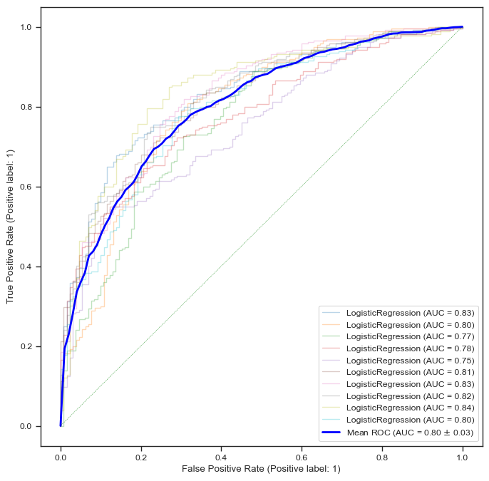

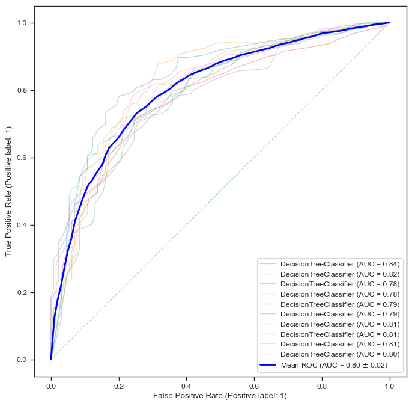

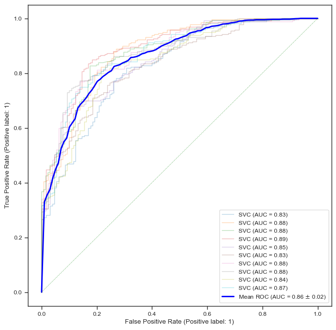

```python
config = [
    (LogisticRegression, {}),
    (DecisionTreeClassifier, {'min_samples_leaf': 50}),
    (SVC, {'kernel': 'rbf', 'gamma': 2}),

]

#results = []
for model_class, setting in config:
    print(model_class.__name__)
    best_model, mean_val, std_val, best_scaler = train(X_train_cv, y_train_cv, model_class, setting)
```

**5-Em relação à questão anterior, qual o modelo deveria ser escolhido para uma eventual operação. Responda essa questão mostrando a comparação de todos os modelos, usando um gráfico mostrando a curva ROC média para cada um dos gráficos e justifique.**

A mellhor AUC foi a CVM, por isso teve o melhor modelo

**6-Com a escolha do melhor modelo, use os dados de vinho tinto, presentes na base original e faça a inferência (não é para treinar novamente!!!) para saber quantos vinhos são bons ou ruins. Utilize o mesmo critério utilizado com os vinhos brancos, para comparar o desempenho do modelo. Ele funciona da mesma forma para essa nova base? Justifique.**

```python
df_red = df[df['type'] == 'red'].copy()
df_red.dropna(inplace=True)
```

```python
var = [
   'fixed acidity',
   'volatile acidity',
   'citric acid',
   'residual sugar',
   'chlorides',
   'free sulfur dioxide',
   'total sulfur dioxide',
   'density',
   'pH',
   'sulphates',
   'alcohol',
]

X_real = df_red[var]
y_real = df_red['opinion']
X_real_scaled = best_scaler.transform(X_real)
y_pred_real   = best_model.predict(X_real_scaled)

print(f"A acurácia real é {100 * accuracy_score(y_real, y_pred_real):.2f} %")
print(f"A sensibilidade real é {100 *  recall_score(y_real, y_pred_real):.2f} %")
print(f"A precisão real é {100*  precision_score(y_real, y_pred_real):.2f} %")
print(f"O F1 Score real =  {f1_score(y_real, y_pred_real):.2f} ")
print(classification_report(y_real, y_pred_real))
```

```
A acurácia real é 53.48 %
A sensibilidade real é 100.00 %
A precisão real é 53.45 %
O F1 Score real =  0.70
              precision    recall  f1-score   support

           0       1.00      0.00      0.00       742
           1       0.53      1.00      0.70       851

    accuracy                           0.53      1593
   macro avg       0.77      0.50      0.35      1593
weighted avg       0.75      0.53      0.37      1593
```

```python
print('Vinhos bons brancos: ')
print(df_white.opinion.sum())
print('---------------------')
print('Vinhos bons tintos: ')
print(df_red.opinion.sum())
print('---------------------')
print('Soma: ')
print(df_red.opinion.sum() + df_white.opinion.sum())
```

```
Vinhos bons brancos:
3240
---------------------
Vinhos bons tintos:
851
---------------------
Soma:
4091
```

```python
print(df.opinion.sum()) #resultado incluindo outliers
```

```
4113
```